# Plotting 2.0: Shiny

#### Part F: Access different datasets with `reactive()`

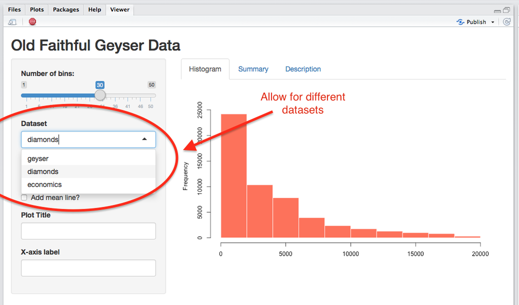

25. Next, we’ll allow the user to plot data from 3 different datasets. To do this, first create a new select input box in the user interface as follows:

```r
# Add a new select input called mydata

selectInput(inputId = "mydata",
             label = "Dataset",
             choices = c("geyser", "diamonds", "economics"),
             selected = "geyser")
```

26. Now, in your server section, we need to define `x` as a *reactive value* that depends on the user’s input to `input$mydata`. To do this, we’ll remove the existing code that defines the object `x` and replace it with `x_reactive()` using the `reactive()` function. The `reactive()` function tells Shiny that `x_reactive` is isn’t a stable value, but will change depending on user input.
- Step 1: Delete all existing code that defines the object `x` (right now you’ll find it in both the `hist()` function and when we defined `output$summary`
- Step 2: Using the following code, define `x_reactive` as a reactive value that can change depending on the `input$mydata`. If you haven’t seen it before, the `switch()` function is a very helpful function that works like a series of if-then statements.

```r
# x is a reactive value that depends on input$mydata
#   This code should replace the previous code that defined x

# Put this code just after the server() function and BEFORE output$distPlot

x_reactive <- reactive({

  switch(input$mydata,  # Look at the value of input$mydata...
         "geyser" = faithful[,2],          # If the value is 'geyser', return data from faithful
         "economics" = economics$unemploy, # if the value is 'economics' return unemployment data
         "diamonds" = diamonds$price)      # If the value is 'diamonds' return price data

})
```

27. Now we need to make one last change. In **all** of the code that refers to `x` we need to replace `x` with `x_reactive()` (Don’t forget the parentheses!!). Make this replacement for `hist()`, `summary()`, and `abline()`. Here is how you can do it:

```r
# Change the value x to x_reactive() in seq(), hist(), abline() and summary()

bins <- seq(min(x_reactive()),   # HERE!!! Change to x_reactive()
            max(x_reactive()),   # HERE!!! Change to x_reactive()
            length.out = input$bins + 1)

# [Skip some code...]

 hist(x_reactive(),              # HERE!!! Change to x_reactive()
      breaks = 10,
      col = input$bincolor,
      border = 'white',
      main = input$main,
      xlab = input$xlab)

# [Skip some code...]

 abline(v = mean(x_reactive()),   # HERE!!! Change to x_reactive()
        lwd = 2,
        lty = 2)

# [Skip some code...]

output$summary <- renderPrint({
   summary(x_reactive())         # HERE!!! Change to x_reactive()
 })
```

28. Reload your app and have fun!! You’re finished!

## Challenges

C1. Now that you have multiple datasets, try removing the Plot title and X-axis label inputs (`input$main`, `input$xlab`), and instead have the plot automatically adjust the plot title and axis label based on the dataset the users selects. Just like we did with `x_reactive()`, you’ll need to assign the main title and x label as reactive values.

C2. Add a new panel called “Table” where the user can view their selected dataset. To do this, in the server code, you’ll need to create a new output called `output$tbl` which is is a rendered version of the data. Then in the UI, you’ll need to include

```r
#### SERVER

# Send a rendered data table to output
#  DATASET should the the data as a dataframe

output$tbl <- renderUI({

  output$mytbl <- DT::renderDataTable(expr = DATASET,
                                      options = list(lengthChange = FALSE))

    DT::dataTableOutput('mytbl')

})

#### UI

# Add the new Table tabpanel
tabsetPanel(type = "tabs",
            tabPanel("Histogram", plotOutput("distPlot")),
            tabPanel("Summary", verbatimTextOutput("summary")),
            tabPanel("Description"),
            tabPanel("Table", uiOutput('tbl')))  # <- HERE!!!
```

C3. Try adding a new panel called `Test` where people can conduct a one-sample t-test on their data and view the results. To do this, you’ll need to create a new output in the server called `output$printttest` which is a call to `renderPrint()`. Inside of `renderPrint()` you’ll create the code for your test, and print the result. Next, in the UI, you’ll need to add a new tab panel, and show the results by running `verbatimTextOutput('printttest')`. Look at the template below for help. If you’d like, you could also add a new user input that allows the user to customise the main arguments for the t.test, like `mu` and `alternative`.

```r
#### SERVER

# Send results of t-test to output
#  DATASET should the the data as a dataframe

# Print Test output

output$printttest <- renderPrint({

  mytest <- t.test(x = DATA, mu = 0, alternative = "two.sided")

    print(mytest)

  })


#### UI

# Add the new Table tabpanel
tabsetPanel(type = "tabs",
            tabPanel("Histogram", plotOutput("distPlot")),
            tabPanel("Summary", verbatimTextOutput("summary")),
            tabPanel("Description"),
            tabPanel("Test", verbatimTextOutput('printttest')))  # <- HERE!!!
```

C4. So far we’ve used base plotting functions (e.g.; `hist()`, `abline()`). Try replacing these functions with ggplot code. For example, you could use `ggplot(data, aes(x)) + geom_hist()` to create a histogram. Note that because of the way you build on plots in ggplot, using the `addmean` functionality will be a bit tricky, so you may wish to remove it.

C5. In the [RStudio Shiny Gallery](https://shiny.rstudio.com/gallery/) at https://shiny.rstudio.com/gallery/, you’ll see a really cool Shiny App called Google Charts Demo. Click on the app, and then look at the underlying code. Try replicating this app yourself by creating a new app, and copying and pasting the Google Charts demo code into your app. Make sure the app runs. Then, try customising it! For example, you could change the default colors, or include the option for an additional filter in addition to the main “year” filter. Alternatively, you could try applying the chart to a dataset we’ve used in the bootcamp (like `mpg` or `diamonds`)